# CANNEX cross-feeding visualization reproducibility

Validation Cases 01-08 and combined Core-6/Core-15 networks

2026-09-12

## Pipeline validation

Eight literature-defined cases were used to test whether the workflow retains expected relationships and excludes expected null relationships. Cases 01 and 02 are matched triad controls: each contains a positive and a negative branch while holding either the recipient or donor constant. Cases 03–05 are independent positive anchors. Case 06 is a partial pathway match, whereas Cases 07–08 are informative non-passes in which target-production potential was recovered but the literature-described donor edge was not reproduced.

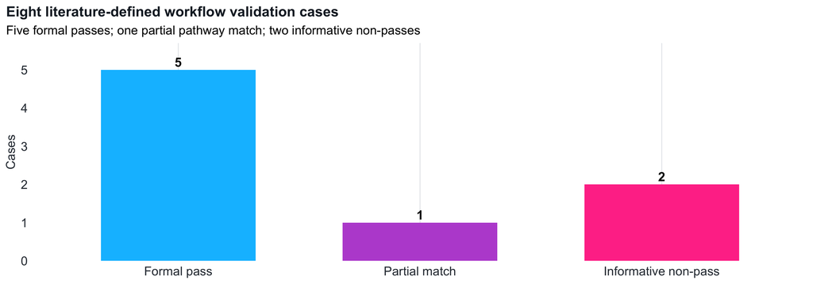

Cases 01 and 02 were matched triad controls expected to retain a literature-supported positive branch while excluding a biologically unsupported donor or recipient branch; the workflow reproduced both outcomes. Cases 03–05 were independent positive controls representing succinate-to-propionate, acetate-to-butyrate, and lactate-to-hydrogen-sulfide cross-feeding, and all three expected relationships were recovered. Case 06 was expected to recover the literature-described *S. gordonii*–ornithine–*F. nucleatum* pathway, but the ornithine donor edge was not retained. Instead, the GEMs supported a potential alternative *S. gordonii*–L-arginine–*F. nucleatum* route to putrescine, resulting in a partial match. Cases 07 and 08 recovered recipient-side indole-3-propionate and deoxycholate production potential, respectively, but did not recover the literature-described indole-3-lactate or cholate donor edges and were classified as informative non-passes. Overall, five cases passed formally, one produced a partial pathway match, and two exposed donor-side limitations in the available GEMs or workflow.

**Figure V1. Pipeline-validation outcomes.** Bars give the number of the eight literature-defined cases classified as a formal pass, partial pathway match, or informative non-pass. Cases 01 and 02 are counted once each even though each contains both a positive and negative branch. Colours indicate outcome class only and do not quantify biological effect size.

The pathway panels use four edge meanings: deep-sky-blue solid arrows are expected relationships retained by the workflow; black dashed T-bars are expected null relationships correctly excluded; medium-orchid arrows are recovered partial or recipient-side results; and violet-red dashed T-bars are literature-expected edges that were not recovered. Grey dashed arrows provide literature-route context only.

### Validation cases 01–02

[interactive chart not shown]

**Figure V2. Matched triad validation controls.** Case 01 holds the recipient constant and contrasts a retained *Bifidobacterium adolescentis* L2-32 L-lactate donor with an excluded *Paraprevotella xylaniphila* YIT 11841 donor. Case 02 holds the donor constant and contrasts retained L-lactate use by *Eubacterium hallii* L2-7 with the excluded negative recipient *Phascolarctobacterium succinatutens* YIT 12067. A dashed T-bar denotes the prespecified absent relationship and therefore contributes to a formal pass.

### Validation cases 03–04

[interactive chart not shown]

**Figure V3. Independent short-chain-fatty-acid validation anchors.** Case 03 shows the retained *P. xylaniphila* YIT 11841 -> succinate -> *P. succinatutens* YIT 12067 -> propionate relationship. Case 04 shows the retained *Bifidobacterium longum* NCC2705 -> acetate -> *Eubacterium rectale* ATCC 33656 -> butyrate relationship. Solid arrows denote retained expected components.

### Validation case 05

[interactive chart not shown]

**Figure V4. Hydrogen-sulfide validation anchor.** Case 05 retained the expected *B. adolescentis* L2-32 -> L-lactate -> *Desulfovibrio piger* ATCC 29098 -> hydrogen-sulfide relationship.

### Validation cases 06–08

[interactive chart not shown]

**Figure V5. Partial and informative non-pass validation cases.** Case 06 recovered putrescine-production potential and a GEM-supported potential alternative *S. gordonii* CH1 -> L-arginine -> *F. nucleatum* ATCC 25586 route, but did not recover the literature-described *S. gordonii* CH1 -> ornithine donor edge. Case 07 recovered indole-3-propionate-production potential in *Clostridium sporogenes* ATCC 15579, but the donor GEM did not represent the expected indole-3-lactate metabolite. Case 08 recovered deoxycholate-production potential and identified cholate on the recipient side, but cholate production was not retained for *Bacteroides thetaiotaomicron* VPI-5482. Violet-red dashed T-bars mark the expected donor components that were not recovered.

## Combined GABA network

This figure contains nine unique Case-2 pathways after combining the two analysis sets. No complete GABA pathway was duplicated between Core-6 and Core-15 after normalizing *Eubacterium rectale* to *Agathobacter rectalis* for display.

[interactive chart not shown]

The GABA network contained four Core-6 Case-2 relationships (two single-precursor and two multi-precursor) and five Core-15 Case-2 relationships (all multi-precursor). No complete relationship was duplicated between the two sets after taxonomic display-name normalization. For every displayed multi-precursor route, at least one exact-path recipient GEM could import and transport every metabolite in the displayed input set.

**Figure F. Literature-supported Case-2 pathways ending in GABA.** The network shows only relationships for which both donor-to-exact-precursor and recipient-to-GABA evidence met the prespecified literature rule. Light-sky-blue edges denote Core-6, steel-blue edges denote Core-15, and slate-blue edges would denote a relationship present in both sets. Node colours distinguish potential donors (deep sky blue), focal precursors (thistle), potential recipients (slate blue), and GABA (pale violet red). A snow-grey intermediate box lists the complete input combination for a displayed multi-precursor path. Edge labels report supporting/tested GEMs (`n/N`); line width denotes low (<=30%), intermediate (>30% to <=70%), or high (>70%) strain-panel support. These are structural-potential relationships, not direct evidence of in vivo metabolite transfer.

## Combined butyrate network

This figure contains eleven unique Case-2 pathways after combining the two analysis sets. No complete butyrate pathway was duplicated between Core-6 and Core-15 after taxonomic display-name normalization.

[interactive chart not shown]

The butyrate network contained five Core-6 Case-2 relationships (three single-precursor and two multi-precursor) and six Core-15 Case-2 relationships (all single-precursor). No complete relationship was duplicated between the two sets after taxonomic display-name normalization. Each displayed multi-precursor input set passed the same exact-path and every-root import requirements used for the GABA network.

**Figure G. Literature-supported Case-2 pathways ending in butyrate.** The network is restricted to relationships with qualifying literature evidence for both the donor-to-exact-precursor and recipient-to-butyrate reactions. Colours, node roles, `n/N` edge labels, line-width thresholds, and snow-grey multi-precursor input boxes are defined as in Figure F. Edge colour identifies the originating analysis set; it does not indicate pathway direction or effect size. The displayed connections remain GEM-supported structural potential rather than experimentally confirmed exchange between the modeled organisms.